# ⚡ NLP & Classificação Distribuída de Reviews com Apache Spark 4.0.1 MLlib

## 6. Slice-Based Error Analysis (Por Estrela Original & Tamanho do Texto)

|  | Dimensão | Fatia | N | Acurácia | Prob Média Positivo | ROC-AUC |
| --- | --- | --- | --- | --- | --- | --- |
| 0 | Nota Original (Estrelas) | 1★ (Não-Positivo) | 1500 | 0.9667 | 0.1089 | NaN |
| 1 | Nota Original (Estrelas) | 2★ (Não-Positivo) | 1500 | 0.9427 | 0.1486 | NaN |
| 2 | Nota Original (Estrelas) | 3★ (Não-Positivo) | 1500 | 0.7533 | 0.3239 | NaN |
| 3 | Nota Original (Estrelas) | 4★ (Positivo) | 1500 | 0.6940 | 0.6333 | NaN |
| 4 | Nota Original (Estrelas) | 5★ (Positivo) | 1500 | 0.8613 | 0.7694 | NaN |
| 5 | Tamanho do Review | Curto (≤40 pal.) | 1328 | 0.8373 | 0.4995 | 0.9232 |
| 6 | Tamanho do Review | Médio (41–120 pal.) | 3076 | 0.8449 | 0.4274 | 0.9232 |
| 7 | Tamanho do Review | Longo (>120 pal.) | 3096 | 0.8450 | 0.3224 | 0.9044 |

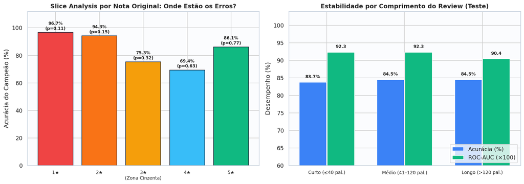

```
Sessão Apache Spark encerrada corretamente.
```

```python
display(pd.DataFrame(metrics["slice_error_analysis"]))
display(Image(filename=str(FIG_DIR / "06_slice_error_analysis.png")))

spark.stop()
print("Sessão Apache Spark encerrada corretamente.")
```

### 🔎 Onde o Modelo Acerta e Onde Estão os Erros?

- **Análise por Nota Original (`1★` a `5★`):**
  - Nos extremos negativos e positivos, o modelo é altamente confiável: **`96.7%`** em **`1★`** (`p = 0.11`), **`94.3%`** em **`2★`** (`p = 0.15`) e **`86.1%`** em **`5★`** (`p = 0.77`).
  - A maior concentração de erros ocorre na **fronteira natural entre `3★` (`75.3%`, `p = 0.32`) e `4★` (`69.4%`, `p = 0.63`)**, onde comentários equilibrados (*"food was good, but service was a bit slow"*) carregam tanto elogios quanto ressalvas — evidenciando uma probabilidade monotonicamente crescente (`0,11 → 0,15 → 0,32 → 0,63 → 0,77`) coerente com a escala ordinal real!
- **Estabilidade por Tamanho do Texto:** O modelo mantém `ROC-AUC` acima de **`0,90`** em todas as faixas — **`0,923`** em textos curtos (`≤40` palavras) e médios (`41–120` palavras) e **`0,904`** em relatos longos (`>120` palavras), com acurácia estável em `83,7%–84,5%`.

## 7. Conclusão Executiva & Recomendação para Produção

1. **Arquitetura Recomendada no Apache Spark:** **`10. LogisticRegression (Híbrido TF-IDF+W2V)`** combinando **TF-IDF Unigramas+Bigramas (`16.384` buckets, preservando negações) + Spark `Word2Vec` (`64D`) + Sinais Estilísticos Escalados**, entregando **`ROC-AUC = 0.9155`**, **`PR-AUC = 0.8778`**, **`F1 = 0.8090`** (em `τ = 0.37`) e **Brier Score = `0.1128`**.
2. **Lição Principal de Engenharia Spark MLlib:** Dimensionar corretamente `HashingTF` (`16k+` buckets), aplicar ponderação `IDF`, incluir bigramas e preservar negações gera um salto de **`+21,3 p.p.` de ROC-AUC** (`+44,5 p.p.` de F1) sobre o pipeline legado (`50` buckets). Unir a precisão léxica esparsa do **TF-IDF (1–2g)** com a generalização semântica densa do **`Word2Vec` nativo (64D)** sob um classificador linear distribuído supera ambas as representações isoladas — além de bater modelos baseados em árvores (`GBT` / `RF`) tanto em qualidade quanto em velocidade.
3. **Pronto para Escala:** Todo o pipeline (tokenização, stopwords, bigramas, TF-IDF, Word2Vec, escalonamento e classificação) roda 100% dentro de `pyspark.ml.Pipeline` distribuído na JVM (sem *Python workers*), podendo ser serializado (`.save()`) e servido diretamente em clusters Spark/Databricks sobre milhões de avaliações.